# HCD Simulations Write Up

Audrey Fu Lab

29 May, 2024

# Data Simulation

### Simulating networks

We adopt a top-down approach to simulate hierarchical networks, considering various simulation parameters such as graph sparsity, noise, and the architecture of the super-level graph(s), including small-world, scale-free, and random graph networks (Watts and Strogatz 1998; Barabási and Bonabeau 2003).

Our simulations focus on basic hierarchies comprising one or two hierarchical layers. Two-layer networks mirror classical community detection on graphs, where our aim is to recover the true community labels from a given graph. Meanwhile, three-layer networks present a more intricate scenario, where the bottom layer of the hierarchy contains two levels of community structure. Here, the top level corresponds to the nodes at the uppermost layer of the hierarchy, and the middle level consists of communities nested within the top-level communities. The objective with these networks is to identify both sets of community partitions.

In each hierarchy, for fully connected networks, we initiate by simulating $n_{\text{top}}$ top-level nodes, adhering to a directed small-world, random graph, or scale-free network architecture (Watts and Strogatz 1998; Barabási and Bonabeau 2003). In cases where the network is disconnected, we simply simulate $n_{\text{top}}$ disconnected nodes. For networks with three hierarchical layers, we then generate a subnetwork of $n_{\text{middle}}$ nodes from each top-layer node, adhering to the network structure utilized at the top level. If the network is fully connected, we apply a probability $p_\text{between}$ to the nodes from different top-level communities being connected.

The final step in all hierarchies is to generate the nodes in the observed (bottom) layer of the hierarchy. For each top-layer or middle-layer node, we generate a subnetwork of $n_{\text{bottom}}$ nodes under the same subnetwork structure as the previous layers, and we apply a probability $p_\text{between}$ for nodes from different communities to share an edge.

### Simulating gene expression

Once we simulate a hierarchical graph, we utilize this hierarchy to generate the node-feature matrix, which depicts the expression of $N$ genes across $p$ samples. Here, $N$ denotes the number of nodes in the observed (bottom) layer of the hierarchy, and its range is governed by $a^{\ell+1}<N<a\times b^\ell$, where $\ell$ signifies the number of hierarchical layers.

We simulate the node-feature matrix using the topological order the observed level graph. We start by generating the features of nodes that have no parental input. We refer to these nodes as *origin* nodes. All origin nodes are simulated from a normal distribution with mean $0$ and standard deviation $\sigma$. All other nodes are simulated from a normal distribution centered at the mean of their parent nodes and with standard deviation $\sigma$.

# Hierarchical Commuity Detection (HCD) Overview

Our HCD method consists of two primary components:

1. A graph autoencoder based on the architecture proposed by Salehi and Davulcu (2019) which utilizes graph attention layers such as those first indroduced by Veličković et al. (2017) (See most recent version of pseudocode for details). In our applications, we incorporate multi-head attention in all encoder and decoder layers to expand model learning capacity. The graph autoencoder module takes a set of node attributes and an adjacency matrix defining the relationships between the node as input and learns a low dimensional embedding of the network and attributes. This embedding is then used to reconstruct the node attributes and adjacency matrix under a separate loss function for each.
2. The second component of HCD takes the embeddings generated by the autoencoder and applies a multilevel community detection process. This module is composed of $l$ fully connected layers, each representing a level in the hierarchy. Each layer’s goal is to group the $k_{i-1}$ nodes from the previous level into $k_i$ communities. The number of layers in the hierarchy and the number of communities at each level are predefined parameters that need to be determined through other methods. In our applications, we use the simulation truth for each parameter so that the communitiy detection module consists of $2$ layers where the first layer assigns the nodes at the bottom layer to the true number of communities at the middle layer. The second community detection layer assigns the nodes in the middle layer to communities in the top layer.

# Datasets

We consider three sets of hierarchical networks which represent varying difficulty levels for inference:

1. **Complex networks** - used for final simulation assessment - **Table** 1.1 - 1.3 .
2. **Intermediate networks** - used for investigative model tuning and performance assessment - **Table** 1.4 .
3. **Simple networks** - used for code implementation and debugging - **Table** 1.5.

# Application to Intermediate Networks

We apply the HCD method to each network separately using three options for the input graph corresponding to the nodes at the observed layer of the hierarchy:

- The input graph is the true graph
- The input graph is the correlation matrix of the simulated gene expression
- The input graph is the correlation matrix of the simulated gene expression wherein correlations weaker than 0.2 are disregarded and set to zero
- The input graph is the correlation matrix of the simulated gene expression wherein correlations weaker than 0.5 are disregarded and set to zero
- The input graph is the correlation matrix of the simulated gene expression wherein correlations weaker than 0.7 are disregarded and set to zero

We also explore various combinations of weighting the loss function across each of the aforementioned input graphs. In all cases, we ensure that the predicted number of communities in the middle or top levels of the hierarchy aligns with the ground truth of the simulation.

### Evaluating performance

We evaluate the performance of our HCD method using three graph-based clustering metrics:

1. **homogeneity** evaluates the degree to which each predicted community contains only data points from a single true community, indicating how well the algorithm avoids mixing different groups. Thus, homogenity tends to be high if resolved communities contain only members of the same true community.
2. **completeness** assesses the extent to which all data points that belong to the same true community are correctly assigned to a single predicted community. Thus completeness is always high if all members of the same true communities end up in the same resolved community even if several true communities are allocated together.
3. **NMI** is a weighted average of the previous two metrics.

For each simulation, we configure the number of communities in the middle and upper layers of the hierarchy to match the true count in each layer. Then, we evaluate the community predictions of the Hierarchical Community Detection (HCD) algorithm at these levels against the actual communities using three metrics. As a baseline, we employ the Louvain method, which utilizes hierarchical graph partitioning to maximize modularity, resulting in a single set of resolved communities. These resolved communities may align with the middle, upper, or a combination of both layers in the true hierarchy. Thus, we compute the performance metrics of the communities identified by the Louvain method against the true communities at both the upper and middle levels of the hierarchy.

# Results

### Comparing small world, scale free, and random graphs: small world disconnected intermediate networks

In this section, we compare HCD and louvain performance on small world, scale free, and random graph networks in this simplest/easiest scenario: 3-layer intermediate networks with origin nodes simulated from $N(\mu_k, \sigma)$ distributions. These three hierarchies are the simplest in terms of the separability of the communities in the middle and top layers. A full summary of the networks in this dataset can be found in *Table* 1.4. We apply HCD with the “best” parameter settings from our previous results outlined in *Report 4/15/2025* which are summarized in **Table** 1.6.

### Issues with loss function

Our loss function combines four components: (i) MSE loss on the reconstructed graph, (ii) BCE loss on the reconstructed graph, (iii) modularity for community predictions summed across all $\ell$ hierarchical layers in the hierarchy, and (iv) the clustering loss measured as the Within Cluster Sum of squares (WCSS) for community predictions summed across all $\ell$ hierarchical layers. Components (i - ii) apply to the graph auto encoder (GATE) and aim to ensure the learned embedding respects the original node attributes and input graph. Components (iii - iv) evaluate the quality of the community predictions where loss component (iii) evalutes their quality relative to the input graph and loss component (iv) evaluates their quality with respect to the node attributes. Currently the WCSS clustering loss component is calculated on the embeddings as follows:

$$L_C = \sum_{\ell=1}^\mathcal{L} \frac{1}{k_{\ell-1}\cdot k_\ell} tr({\bf D}_\ell^T {\bf D}_\ell) \tag{1}\label{eq:eq1}$$

where $\ell$ is the number of hierarchical layers, $k_\ell$ is the number predicted communities in the $\ell^{th}$ hierarchical graph, and where ${\bf D}_\ell \in \mathbb{R}^{q \times k_\ell}$ is a matrix of node deviations computed as:

$${\bf D}_\ell =\left[{\bf \tilde X}^{(\ell-1)}\right]^T - {\bf M}_\ell{\bf P}_\ell^T \tag{2}\label{eq:eq2}$$

where ${\bf \tilde X}^{(\ell - 1)} \in \mathbb{R}^{N \times q}$ is the node embedding in the preceding hierarchical layer, ${\bf P}_\ell \in \mathbb{R}^{k_{\ell-1} \times k_\ell}$ is a matrix of community assignment probabilities, and ${\bf M}_\ell \in \mathbb{R}^{q\times k_\ell}$ is matrix of community centroids. One challenge with defining the clustering loss component on the model embedding is that it creates a bias which encourages the model to shift the positions of the nodes in the embedding space so that they are closer together enabling a better score on the loss function.

To help illustrate this, we present three more examples outlined in **Table** 1.8 where we apply HCD to a small world network with 3 layers and origin nodes simulated from different distributions. In the first example, **Clustering Loss Example 1**, we apply HCD with the usual parameters settings and the clustering loss as defined above. In this example, the clustering bias is made apparent when comparing the nodes and their true communities in both the PCA and embedding spaces. As can be seen in **Figure** 2.2 the top layer communities are completely separated in the PC space and so should be easily detected, however, we can see that they are more ambiguous when viewed in the embedding space. The final predictions from this example lead to parts of two communities to be merged into a single super-community. In effect the model has cheated to get a better overall loss (**Table** 1.9, **Figures** 2.3 - 2.6).

To address this bias, we adjust the clustering loss function given **eq 1** to compute the loss using the original node attributes. Since the node features remain unchanged through the training process the model is not encouraged to manipulate their presentations in the embedding space. To compute the loss using the original node attributes, we must know the mapping between the original $N$ nodes to their community representations in higher hierarchical layers. This can be done through a simple multiplication of the assignment probabilities from previous layers:

$${\bf Q}_\ell = \bf{P}_1 \otimes {\bf P_2} \otimes \cdots \otimes {\bf P}_{\ell -1}$$

Where the operation ${\bf Q}_\ell = {\bf P}_{\ell -1 } \otimes {\bf P}_\ell$ is the dot product between matrices ${\bf P}_{\ell -1 }$ and ${\bf P}_\ell$ where the elements in $\bf Q$ are computed as

$$q_{i,j} = {\bf p}_{\ell -1,i}^T \circ {\bf p}_{\ell,j} = \sum_{s = 1}^{k_{\ell - 1}} p_{i,s}^{(\ell - 1)} \cdot p_{s,j}^{(\ell)}$$

this is akin to computing the marginal probability of assigning node $n_i$ to community $C_k$ in the $\ell^{th}$ hierarchical layer:

$$= \sum_{m = 1}^{k_{\ell - 1}}Pr\left( n_i \in C_m^{(\ell - 1)}\right) \cdot Pr\left(n_i \in C_{k}^{(\ell)}| n_i \in C_m^{(\ell - 1)} \ \right)$$

We present the results from **Cluster Loss Example 2** which uses the above clustering loss computed on the original node features applied to the same network as in Cluster Loss Example 1. As can be seen in **Figures** 2.4 - 2.7 and **Table** 1.9, using the node attributes to compute the cluster loss leads to perfect clustering performance on the top layer communities, but the middle layer communities are no longer detectable. This is possible due to a known issue with k-means like optimization in which communities that are too small or nested within larger structures are undetectable.

In **Cluster Loss Example 3** we again apply the HCD model with the same clustering loss component as in Cluster Loss Example 1, but this time we increase the attribute reconstruction loss to see if the bias in the model’s predictions were due to the attribute reconstruction have negligable influence on the total loss. As can be seen in **Table** 1.9, this did little to improve performance. However, increasing the attribute reconstruction loss component does appear to prevent overgrouping as all five communities are detected to some degree (**Figures** 2.5 - 2.8). This suggest that with further refinement of this parameter, the loss computed on the embeddings can detect the true communities and further provide some community-level information about intermediate layers in the hierarchy.

# 1 Tables

Table 1.1: Summary statistics for all small world networks in the complex networks datset

| Subgraph type | Connect. type | Layers | StDev. | Nodes per layer | Edges per layer | Subgraph prob. | Sample size | Modularity (top) | Avg. node degree top | Avg edges within communities (top) | Avg. edges between communities (top) | Modularity (middle) | Avg. node degree middle | Avg edges within communities (middle) | Avg edges between communities (middle) |
| --- | --- | --- | --- | --- | --- | --- | --- | --- | --- | --- | --- | --- | --- | --- | --- |
| small world | disc | 2 | 0.1 | (10, 63) | (0, 63) | 0.05 | 500 | 0.90 | 1.00 | 6.3 | 0.00 | NA | NA | NA | NA |
| small world | disc | 2 | 0.5 | (10, 63) | (0, 63) | 0.05 | 500 | 0.90 | 1.00 | 6.3 | 0.00 | NA | NA | NA | NA |
| small world | disc | 3 | 0.1 | (10, 63, 1604) | (0, 63, 2011) | 0.05 | 500 | 0.90 | 1.25 | 201.1 | 0.00 | 0.76 | 1.25 | 24.82 | 0.11 |
| small world | disc | 3 | 0.5 | (10, 63, 1604) | (0, 63, 2031) | 0.05 | 500 | 0.90 | 1.27 | 203.1 | 0.00 | 0.76 | 1.27 | 24.97 | 0.12 |
| small world | full | 2 | 0.1 | (10, 63) | (45, 115) | 0.05 | 500 | 0.45 | 1.82 | 6.3 | 0.58 | NA | NA | NA | NA |
| small world | full | 2 | 0.5 | (10, 63) | (45, 109) | 0.05 | 500 | 0.48 | 1.73 | 6.3 | 0.51 | NA | NA | NA | NA |
| small world | full | 3 | 0.1 | (10, 63, 1604) | (45, 114, 1604) | 0.05 | 500 | 0.77 | 1.43 | 199.3 | 3.39 | 0.67 | 1.43 | 24.94 | 0.19 |
| small world | full | 3 | 0.5 | (10, 63, 1604) | (45, 111, 1604) | 0.05 | 500 | 0.77 | 1.44 | 201.3 | 3.28 | 0.66 | 1.44 | 24.87 | 0.19 |

Table 1.2: Summary statistics for all scale free networks in the complex networks datset

| Subgraph type | Connect. type | Layers | StDev. | Nodes per layer | Edges per layer | Subgraph prob. | Sample size | Modularity (top) | Avg. node degree top | Avg edges within communities (top) | Avg. edges between communities (top) | Modularity (middle) | Avg. node degree middle | Avg edges within communities (middle) | Avg edges between communities (middle) |
| --- | --- | --- | --- | --- | --- | --- | --- | --- | --- | --- | --- | --- | --- | --- | --- |
| scale free | disc | 2 | 0.1 | (10, 58) | (0, 74) | 0.05 | 500 | 0.89 | 1.28 | 7.4 | 0.00 | NA | NA | NA | NA |
| scale free | disc | 2 | 0.5 | (10, 58) | (0, 74) | 0.05 | 500 | 0.89 | 1.28 | 7.4 | 0.00 | NA | NA | NA | NA |
| scale free | disc | 3 | 0.1 | (10, 58, 1450) | (0, 74, 6700) | 0.05 | 500 | 0.89 | 4.62 | 670.0 | 0.00 | 0.91 | 4.62 | 107.07 | 0.15 |
| scale free | disc | 3 | 0.5 | (10, 58, 1450) | (0, 74, 6670) | 0.05 | 500 | 0.89 | 4.60 | 667.0 | 0.00 | 0.91 | 4.60 | 107.07 | 0.14 |
| scale free | full | 2 | 0.1 | (10, 58) | (45, 120) | 0.05 | 500 | 0.51 | 2.07 | 7.4 | 0.51 | NA | NA | NA | NA |
| scale free | full | 2 | 0.5 | (10, 58) | (45, 120) | 0.05 | 500 | 0.51 | 2.07 | 7.4 | 0.51 | NA | NA | NA | NA |
| scale free | full | 3 | 0.1 | (10, 58, 1450) | (45, 123, 1450) | 0.05 | 500 | 0.85 | 4.78 | 665.9 | 3.03 | 0.88 | 4.78 | 107.07 | 0.22 |
| scale free | full | 3 | 0.5 | (10, 58, 1450) | (45, 122, 1450) | 0.05 | 500 | 0.85 | 4.84 | 671.4 | 3.42 | 0.86 | 4.84 | 107.07 | 0.25 |

Table 1.3: Summary statistics for all random graph networks in the complex networks datset

| Subgraph type | Connect. type | Layers | StDev. | Nodes per layer | Edges per layer | Subgraph prob. | Sample size | Modularity (top) | Avg. node degree top | Avg edges within communities (top) | Avg. edges between communities (top) | Modularity (middle) | Avg. node degree middle | Avg edges within communities (middle) | Avg edges between communities (middle) |
| --- | --- | --- | --- | --- | --- | --- | --- | --- | --- | --- | --- | --- | --- | --- | --- |
| random graph | disc | 2 | 0.1 | (10, 45) | (0, 32) | 0.05 | 500 | 0.88 | 0.71 | 3.2 | 0.00 | NA | NA | NA | NA |
| random graph | disc | 2 | 0.5 | (10, 45) | (0, 32) | 0.05 | 500 | 0.88 | 0.71 | 3.2 | 0.00 | NA | NA | NA | NA |
| random graph | disc | 3 | 0.1 | (10, 45, 725) | (0, 32, 678) | 0.05 | 500 | 0.89 | 0.94 | 67.8 | 0.00 | 0.78 | 0.94 | 12.16 | 0.07 |
| random graph | disc | 3 | 0.5 | (10, 45, 725) | (0, 32, 665) | 0.05 | 500 | 0.88 | 0.92 | 66.5 | 0.00 | 0.80 | 0.92 | 12.22 | 0.06 |
| random graph | full | 2 | 0.1 | (10, 45) | (45, 77) | 0.05 | 500 | 0.31 | 1.71 | 3.2 | 0.50 | NA | NA | NA | NA |
| random graph | full | 2 | 0.5 | (10, 45) | (45, 77) | 0.05 | 500 | 0.31 | 1.71 | 3.2 | 0.50 | NA | NA | NA | NA |
| random graph | full | 3 | 0.1 | (10, 45, 725) | (45, 78, 725) | 0.05 | 500 | 0.76 | 1.04 | 65.5 | 1.10 | 0.70 | 1.04 | 12.18 | 0.10 |
| random graph | full | 3 | 0.5 | (10, 45, 725) | (45, 78, 725) | 0.05 | 500 | 0.72 | 1.09 | 65.7 | 1.48 | 0.67 | 1.09 | 12.16 | 0.12 |

Table 1.4: Summary statistics for intermediate difficulty simulated networks.

| Subgraph type | Connect. type | Layers | StDev. | Nodes per layer | Edges per layer | Subgraph prob. | Sample size | Modularity (top) | Avg. node degree top | Avg edges within communities (top) | Avg. edges between communities (top) | Modularity (middle) | Avg. node degree middle | Avg edges within communities (middle) | Avg edges between communities (middle) |
| --- | --- | --- | --- | --- | --- | --- | --- | --- | --- | --- | --- | --- | --- | --- | --- |
| small world | disc | 3 | 0.1 | (5, 15, 300) | (0, 15, 363) | 0.05 | 500 | 0.80 | 1.21 | 72.6 | 0.00 | 0.76 | 1.21 | 20.00 | 0.30 |
| small world | full | 3 | 0.1 | (5, 15, 300) | (10, 25, 300) | 0.05 | 500 | 0.68 | 1.35 | 70.8 | 2.50 | 0.68 | 1.35 | 20.00 | 0.50 |
| scale free | disc | 3 | 0.1 | (5, 15, 300) | (0, 10, 975) | 0.05 | 500 | 0.78 | 3.25 | 195.0 | 0.00 | 0.86 | 3.25 | 61.33 | 0.26 |
| scale free | full | 3 | 0.1 | (5, 15, 300) | (10, 20, 300) | 0.05 | 500 | 0.73 | 3.35 | 191.4 | 2.40 | 0.84 | 3.35 | 61.33 | 0.41 |
| random graph | disc | 3 | 0.1 | (5, 12, 167) | (0, 7, 138) | 0.05 | 500 | 0.79 | 0.83 | 27.6 | 0.00 | 0.76 | 0.83 | 9.67 | 0.17 |
| random graph | full | 3 | 0.1 | (5, 12, 167) | (10, 17, 167) | 0.05 | 500 | 0.64 | 0.92 | 26.2 | 1.15 | 0.67 | 0.92 | 9.75 | 0.28 |

Table 1.5: Summary statistics for simple simulated networks. These networks contain fewer than 100 nodes at the observed level and only cover small world subgraph architecture.

| Subgraph type | Connect. type | Layers | StDev. | Nodes per layer | Edges per layer | Subgraph prob. | Sample size | Modularity (top) | Avg. node degree top | Avg edges within communities (top) | Avg. edges between communities (top) | Modularity (middle) | Avg. node degree middle | Avg edges within communities (middle) | Avg edges between communities (middle) |
| --- | --- | --- | --- | --- | --- | --- | --- | --- | --- | --- | --- | --- | --- | --- | --- |
| small world | disc | 2 | 0.1 | (2, 6) | (0, 6) | 0.05 | 500 | 0.50 | 1.00 | 3 | 0.0 | NA | NA | NA | NA |
| small world | disc | 3 | 0.1 | (2, 6, 18) | (0, 6, 24) | 0.05 | 500 | 0.50 | 1.33 | 12 | 0.0 | 0.58 | 1.33 | 3 | 0.20 |
| small world | full | 2 | 0.1 | (2, 6) | (1, 7) | 0.05 | 500 | 0.36 | 1.17 | 3 | 0.5 | NA | NA | NA | NA |
| small world | full | 3 | 0.1 | (2, 6, 18) | (1, 7, 18) | 0.05 | 500 | 0.46 | 1.39 | 12 | 0.5 | 0.55 | 1.39 | 3 | 0.23 |

Table 1.6: HCD settings for Examples 8-11.

| Parameter | Example 8 |  | Example 9 | Example 10 | Example 11 |
| --- | --- | --- | --- | --- | --- |
| Hidden Layer Dimensions: | [256, 128, 64, 32] |  | [256, 128, 64, 32] | [256, 128, 64, 32] | [256, 128, 64, 32] |
| X_loss: | 0.0001 |  | 0.0001 | 0.0001 | 0.0001 |
| Modularity_loss: | 0.001 |  | 0.001 | 0.001 | 0.001 |
| Clustering_loss: | [0.001, 0.0001] |  | [0.001, 0.0001] | [0.001, 0.0001] | [0.0001, 1e-05] |
| Learning_rate: | 1e-05 |  | 1e-05 | 1e-05 | 1e-05 |
| True Comms: | True |  | True | True | True |
| Epochs: | 500 |  | 500 | 500 | 500 |
| Multi Head Attn: | True |  | True | True | True |
| Use Attention: | True |  | True | True | True |
| Attn. Heads: | 10 |  | 10 | 10 | 10 |
| Normalize_inputs: | True |  | True | True | True |
| Input Graph | True Graph |  | True Graph | True Graph | True Graph |
| Layers | 3 |  | 3 | 3 | 3 |
| Network Type | Scale Free/Disconnected |  | Random Graph/Disconnected | Small World/Disconnected | Small World/Disconnected |
| Dataset | Intermediate Networks |  | Intermediate Networks | Intermediate Networks | Intermediate Networks |
| Origin Node Dist. | $N(\mu_k, \sigma)$ |  | $N(\mu_k, \sigma)$ | $N(\mu_k, \sigma)$ | $N(\mu_k, \sigma)$ |
| Network ID: | 3L-SF-DiffDist-Inter |  | 3L-SMW-DiffDist-Inter | 3L-RG-DiffDist-Inter | 3L-SMW-DiffDist-Inter |

Table 1.7: Performance metrics for Louvain method and HCD in Examples 8-11. For details regarding parameter settings see Examples 8-11 under section *Examples*. All networks are disconnected with 3 layers and all origin nodes are simulated from a normal distribution with unique center.

| Comparison | Homogeneity | Completeness | NMI | Comparison | Homogeneity | Completeness | NMI |
| --- | --- | --- | --- | --- | --- | --- | --- |
|  | **Example 8:** | **Scale Free** |  |  | **Example 10:** | **Small World** |  |
| **louvain vs middle** | 0.8878 | 0.9891 | 0.9357 | **louvain vs middle** | 0.6508 | 0.9038 | 0.7568 |
| **louvain vs top** | 1 | 0.6622 | 0.7968 | **louvain vs top** | 1 | 0.8253 | 0.9043 |
| **HCD: middle vs middle** | 0.8665 | 0.8981 | 0.882 | **HCD: middle vs middle** | 0.5298 | 0.6337 | 0.5771 |
| **HCD: middle vs top** | 0.8759 | 0.5396 | 0.6678 | **HCD: middle vs top** | 0.8145 | 0.579 | 0.6769 |
| **HCD: top vs top** | 0.5321 | 0.6191 | 0.5723 | **HCD: top vs top** | 0.7768 | 0.9269 | 0.8452 |
|  | **Example 9:** | **Random Graph** |  |  | **Example 11:** | **Small World** |  |
| **louvain vs middle** | 0.8125 | 0.6267 | 0.7076 | **louvain vs middle** | 0.6518 | 0.8342 | 0.7318 |
| **louvain vs top** | 1 | 0.4969 | 0.6639 | **louvain vs top** | 1 | 0.7606 | 0.864 |
| **HCD: middle vs middle** | 0.506 | 0.5239 | 0.5147 | **HCD: middle vs middle** | 0.6699 | 0.6953 | 0.6824 |
| **HCD: middle vs top** | 0.6389 | 0.4262 | 0.5113 | **HCD: middle vs top** | 1 | 0.6169 | 0.7631 |
| **HCD: top vs top** | 0.4352 | 0.4434 | 0.4392 | **HCD: top vs top** | 1 | 1 | 1 |

Table 1.8: HCD settings for Loss Examples 1-3.

| Parameter | Clustering Loss Example 1 |  | Clustering Loss Example 2 | Clustering Loss Example 3 |
| --- | --- | --- | --- | --- |
| Hidden Layer Dimensions: | [256, 128, 64, 32] |  | [256, 128, 64, 32] | [256, 128, 64, 32] |
| X_loss: | 0.0001 |  | 0.0001 | 0.001 |
| Modularity_loss: | 0.001 |  | 0.001 | 0.001 |
| Clustering_loss: | [0.001, 0.0001] |  | [0.001, 0.0001] | [0.001, 0.0001] |
| Learning_rate: | 1e-05 |  | 1e-05 | 1e-05 |
| Comms Layers: | [15, 5] |  | [15, 5] | [15, 5] |
| Epochs: | 500 |  | 500 | 500 |
| Multi Head Attn: | True |  | True | True |
| Use Attention: | True |  | True | True |
| Attn. Heads: | 20 |  | 20 | 20 |
| Normalize_inputs: | True |  | True | True |
| Input Graph | True Graph |  | True Graph | True Graph |
| Layers | 3 |  | 3 | 3 |
| Network Type | Small World/Disconnected |  | Small World/Disconnected | Small World/Disconnected |
| Dataset | Intermediate Networks |  | Intermediate Networks | Intermediate Networks |
| Origin Node Dist. | $N(\mu_k, \sigma)$ |  | $N(\mu_k, \sigma)$ | $N(\mu_k, \sigma)$ |
| Network ID: | Special-3L-SMW-DiffDist-Inter |  | Special-3L-SMW-DiffDist-Inter | Special-3L-SMW-DiffDist-Inter |

Table 1.9: Performance metrics for Louvain method and HCD in Loss Examples 1 - 3. In these examples, two versions of the clustering loss component of HCD are compared on a small world 3 layer disconnected network with unique parent nodes (i.e simulated from different distributions). For specific details regarding the parameter settings see Loss Examples 1 - 3 under section *Examples*. The same network is used in both examples and HCD and the Louvain method are applied to the same data. In example 1, the clustering loss is computed using the node embeddings. In example 2, the clustering loss is computed using the original node attributes.

| Comparison | Clustering Loss Example 1 Homogeneity | Clustering Loss Example 1 Completeness | Clustering Loss Example 1 NMI | Clustering Loss Example 1 | Clustering Loss Example 2 Homogeneity | Clustering Loss Example 2 Completeness | Clustering Loss Example 2 NMI | Clustering Loss Example 3 | Clustering Loss Example 3 Homogeneity | Clustering Loss Example 3 Completeness | Clustering Loss Example 3 NMI |
| --- | --- | --- | --- | --- | --- | --- | --- | --- | --- | --- | --- |
| louvain vs middle | 0.744 | 0.938 | 0.830 |  | 0.705 | 0.895 | 0.788 |  | 0.688 | 0.849 | 0.760 |
| louvain vs top | 1.000 | 0.749 | 0.856 |  | 1.000 | 0.754 | 0.860 |  | 1.000 | 0.734 | 0.847 |
| HCD: middle vs middle | 0.657 | 0.677 | 0.667 |  | 0.644 | 0.947 | 0.767 |  | 0.640 | 0.729 | 0.682 |
| HCD: middle vs top | 0.916 | 0.561 | 0.696 |  | 1.000 | 0.874 | 0.932 |  | 0.902 | 0.610 | 0.728 |
| HCD: top vs top | 0.782 | 0.817 | 0.799 |  | 1.000 | 1.000 | 1.000 |  | 0.810 | 0.829 | 0.820 |

Table 1.10: HCD settings for Examples 12-14.

| Parameter | Example 12 |  | Example 13 | Example 14 |
| --- | --- | --- | --- | --- |
| Hidden Layer Dimensions: | [256, 128, 64, 32] |  | [256, 128, 64, 32] | [256, 128, 64, 32] |
| X_loss: | 0.0001 |  | 0.0001 | 0.0001 |
| Modularity_loss: | 0.001 |  | 0.001 | 0.001 |
| Clustering_loss: | [0.001, 0.0001] |  | [0.001, 0.0001] | [0.001, 0.0001] |
| Learning_rate: | 1e-05 |  | 1e-05 | 1e-05 |
| True Comms: | True |  | True | True |
| Epochs: | 500 |  | 500 | 500 |
| Multi Head Attn: | True |  | True | True |
| Use Attention: | True |  | True | True |
| Attn. Heads: | 10 |  | 10 | 10 |
| Normalize_inputs: | True |  | True | True |
| Input Graph | True Graph |  | True Graph | True Graph |
| Layers | 3 |  | 3 | 3 |
| Network Type | Small World/Disconnected |  | Scale Free/Disconnected | Random Graph/Disconnected |
| Dataset | Intermediate Networks |  | Intermediate Networks | Intermediate Networks |
| Origin Node Dist. | $N(\mu_k, \sigma)$ |  | $N(\mu_k, \sigma)$ | $N(\mu_k, \sigma)$ |
| Network ID: | 3L-RG-DiffDist-Inter |  | 3L-SF-DiffDist-Inter | 3L-SMW-DiffDist-Inter |

Table 1.11: Performance metrics for Louvain method and HCD in Examples 12-14. For details regarding parameter settings see Examples 12-14 under section *Examples*. All networks are disconnected with 3 layers and all origin nodes are simulated from a normal distribution with unique center.

| Comparison | Homogeneity | Completeness | NMI | Comparison | Homogeneity | Completeness | NMI |
| --- | --- | --- | --- | --- | --- | --- | --- |
|  | **Example 12:** | **Small World** |  |  | **Example 14:** | **Random Graph** |  |
| **louvain vs middle** | 0.642 | 0.8676 | 0.7379 | **louvain vs middle** | 0.9539 | 0.5499 | 0.6976 |
| **louvain vs top** | 1 | 0.8031 | 0.8908 | **louvain vs top** | 1 | 0.3714 | 0.5417 |
| **HCD: middle vs middle** | 0.6583 | 0.7751 | 0.7119 | **HCD: middle vs middle** | 0.3324 | 0.3394 | 0.3359 |
| **HCD: middle vs top** | 0.9683 | 0.6776 | 0.7973 | **HCD: middle vs top** | 0.264 | 0.1736 | 0.2095 |
| **HCD: top vs top** | 0.8249 | 0.8276 | 0.8262 | **HCD: top vs top** | 0.1244 | 0.1406 | 0.132 |
|  | **Example 13:** | **Scale Free** |  |  |  |  |  |
| **louvain vs middle** | 0.8347 | 0.8929 | 0.8628 |  |  |  |  |
| **louvain vs top** | 1 | 0.6357 | 0.7773 |  |  |  |  |
| **HCD: middle vs middle** | 0.8353 | 0.8708 | 0.8527 |  |  |  |  |
| **HCD: middle vs top** | 0.9097 | 0.5636 | 0.696 |  |  |  |  |
| **HCD: top vs top** | 0.4856 | 0.5327 | 0.5081 |  |  |  |  |

# 2 Figures

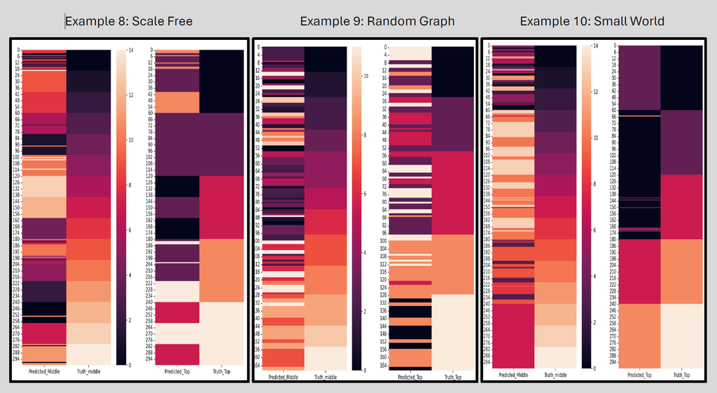

Figure 2.1: Prediction performance for Examples 8-10

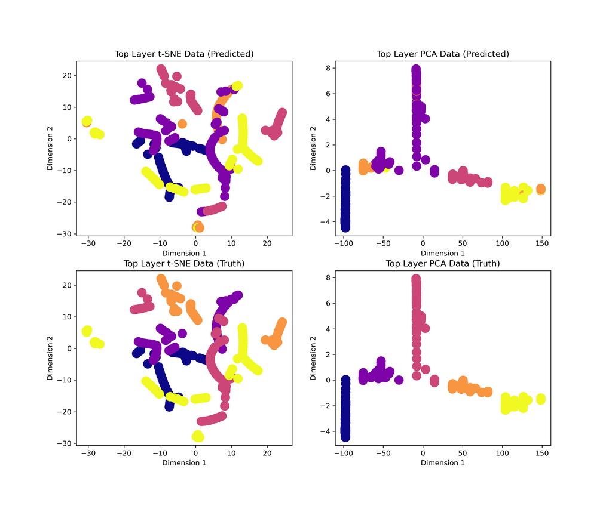

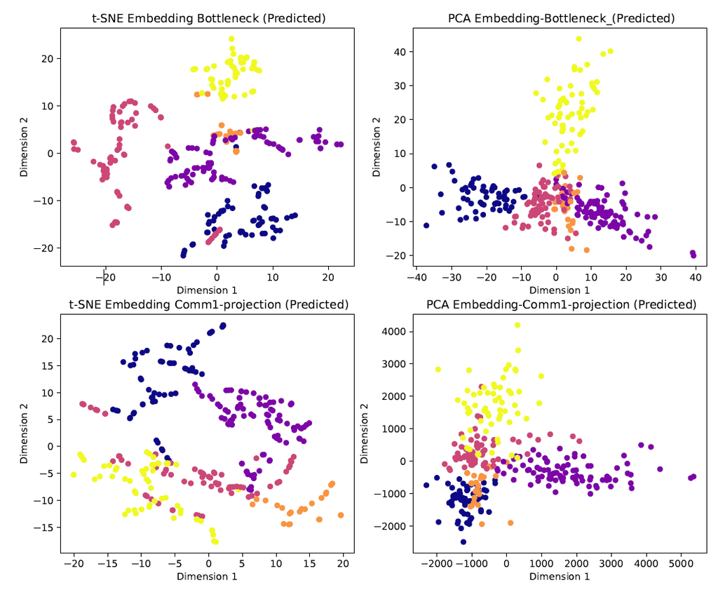

Figure 2.3: TSNE/PCA of node embeddings at the bottleneck layer of GATE (top) and the first hierarchical layer (bottom). Colors indicate the predicted community assignments at the top layer of the hierarchy for Clustering Loss Example 1

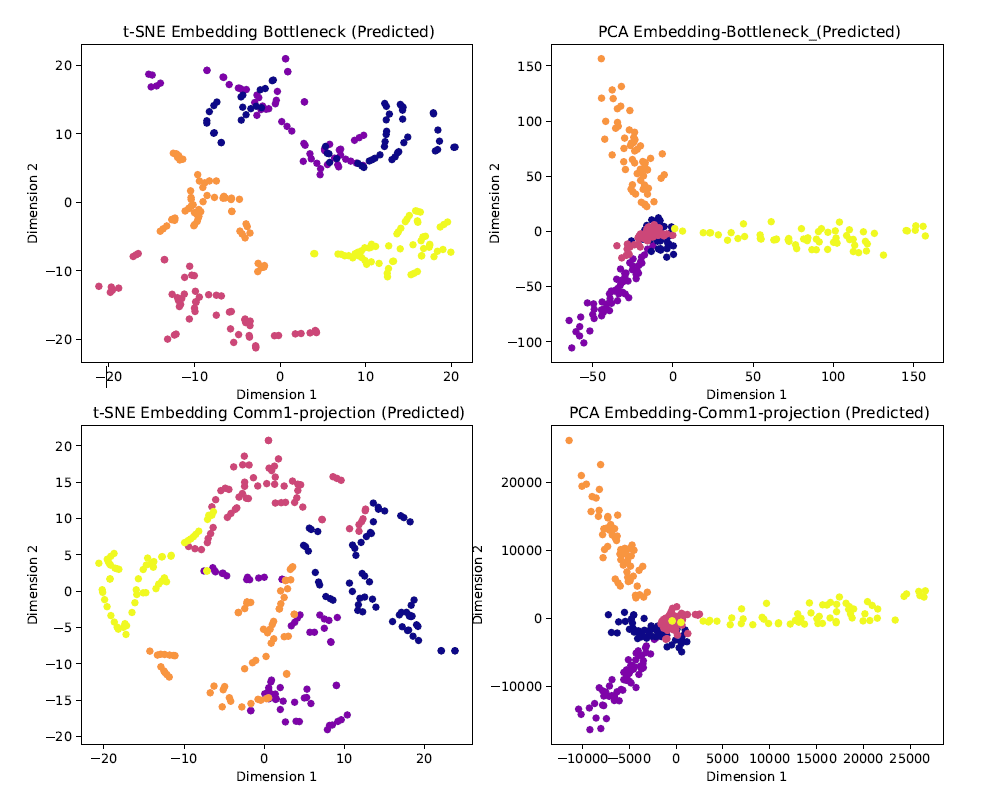

Figure 2.4: TSNE/PCA of node embeddings at the bottleneck layer of GATE (top) and the first hierarchical layer (bottom). Colors indicate the predicted community assignments at the top layer of the hierarchy for Clustering Loss Example 2

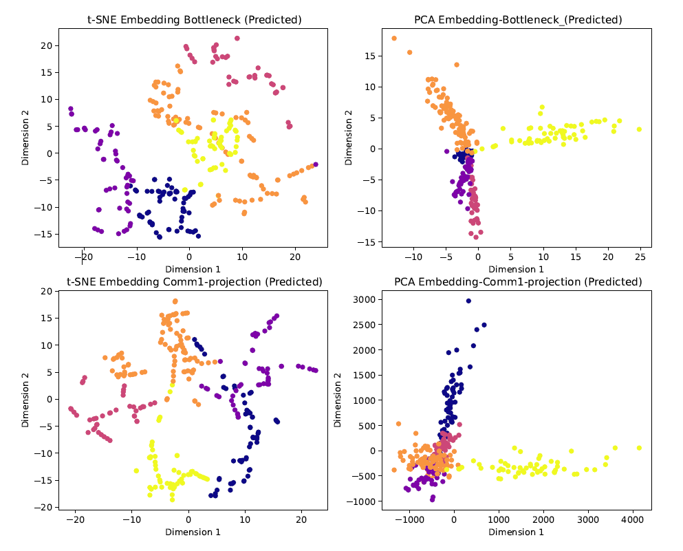

Figure 2.5: TSNE/PCA of node embeddings at the bottleneck layer of GATE (top) and the first hierarchical layer (bottom). Colors indicate the predicted community assignments at the top layer of the hierarchy for Clustering Loss Example 3

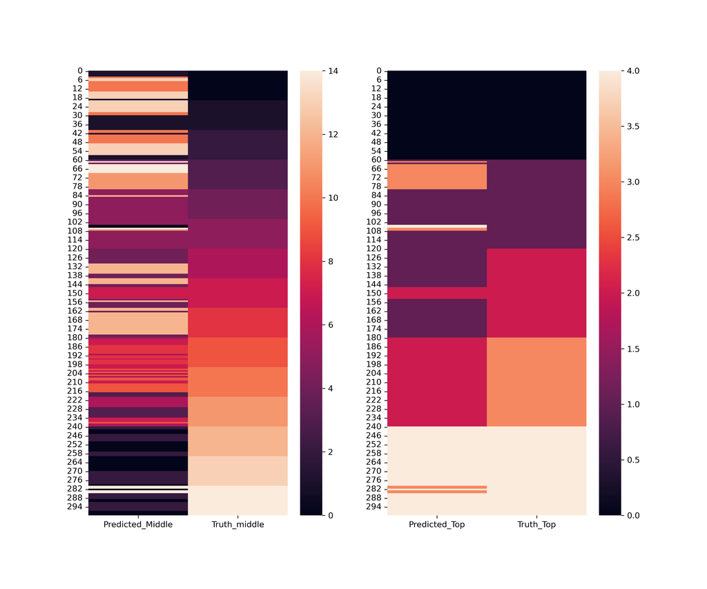

Figure 2.6: Prediction performance for Clustgering Loss Example 1

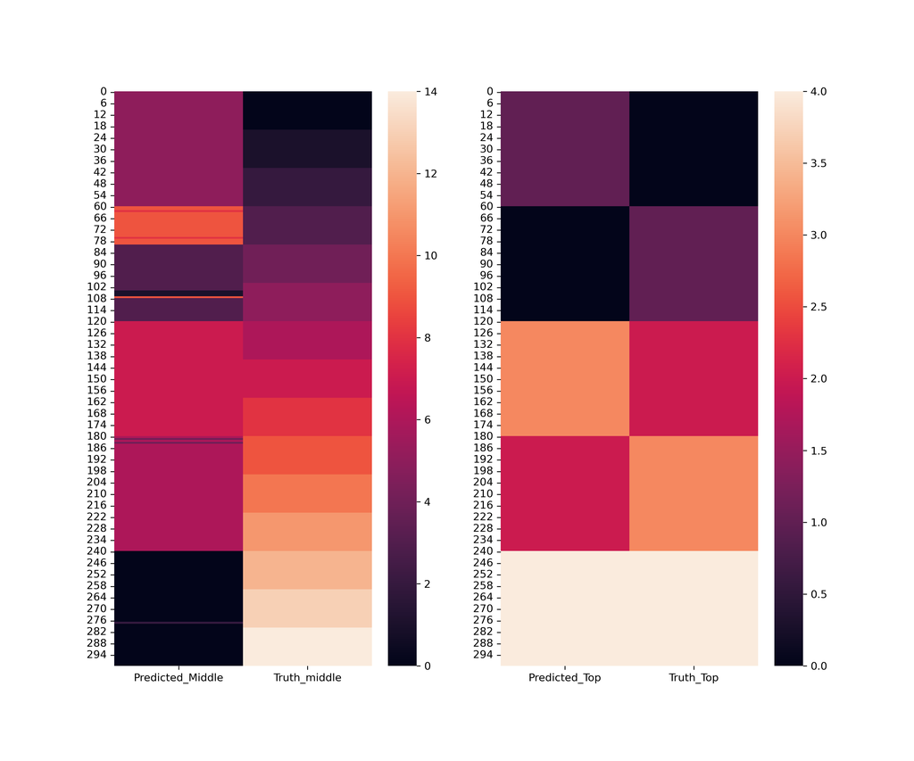

Figure 2.7: Prediction performance for Clustering Loss Example 2

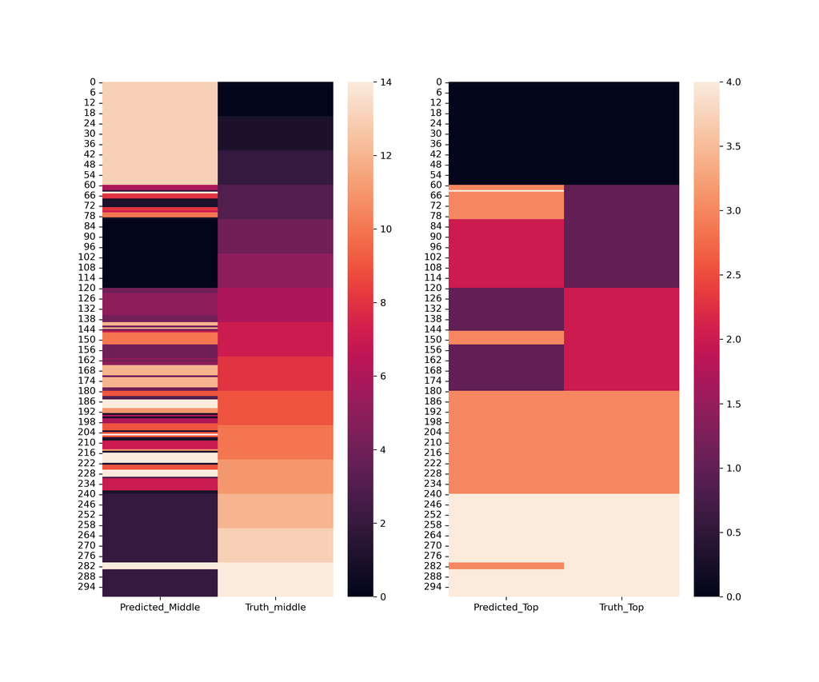

# 3 References

Barabási, Albert-László, and Eric Bonabeau. 2003. “Scale-Free Networks.” *Scientific American* 288 (5): 60–69.

Salehi, Amin, and Hasan Davulcu. 2019. “Graph Attention Auto-Encoders.” *arXiv Preprint arXiv:1905.10715*.

Veličković, Petar, Guillem Cucurull, Arantxa Casanova, Adriana Romero, Pietro Lio, and Yoshua Bengio. 2017. “Graph Attention Networks.” *arXiv Preprint arXiv:1710.10903*.

Watts, Duncan J, and Steven H Strogatz. 1998. “Collective Dynamics of ‘Small-World’networks.” *Nature* 393 (6684): 440–42.